# Project 6: Randomization and Matching

# Introduction

In this project, you will explore the question of whether college education causally affects political participation. Specifically, you will use replication data from by former Berkeley PhD students John Henderson and Sara Chatfield. Their paper is itself a replication study of by Cindy Kam and Carl Palmer. In their original 2008 study, Kam and Palmer argue that college education has no effect on later political participation, and use the propensity score matching to show that pre-college political activity drives selection into college and later political participation. Henderson and Chatfield in their 2011 paper argue that the use of the propensity score matching in this context is inappropriate because of the bias that arises from small changes in the choice of variables used to model the propensity score. They use (at that point a new method), which uses an approach similar to optimal matching to optimize Mahalanobis distance weights. Even with genetic matching, they find that balance remains elusive however, thus leaving open the question of whether education causes political participation.

You will use these data and debates to investigate the benefits and pitfalls associated with matching methods. Replication code for these papers is available online, but as you’ll see, a lot has changed in the last decade or so of data science! Throughout the assignment, use tools we introduced in lab from the and the packages. Specifically, try to use dplyr, tidyr, purrr, stringr, and ggplot instead of base R functions. While there are other matching software libraries available, MatchIt tends to be the most up to date and allows for consistent syntax.

# Data

```r
# Load tidyverse and MatchIt
# Feel free to load other libraries as you wish
library(tidyverse)
library(MatchIt)


# Load ypsps data
ypsps <- read_csv('data/ypsps.csv')
head(ypsps)
```

```
## # A tibble: 6 × 174
##   interviewid college student_vote student_meeting student_other student_button
##         <dbl>   <dbl>        <dbl>           <dbl>         <dbl>          <dbl>
## 1           1       1            1               0             0              0
## 2           2       1            1               1             1              1
## 3           3       1            1               0             0              1
## 4           4       0            0               0             0              0
## 5           5       1            1               1             0              0
## 6           6       1            1               0             0              0
## # ℹ 168 more variables: student_money <dbl>, student_communicate <dbl>,
## #   student_demonstrate <dbl>, student_community <dbl>, student_ppnscal <dbl>,
## #   student_PubAff <dbl>, student_Newspaper <dbl>, student_Radio <dbl>,
## #   student_TV <dbl>, student_Magazine <dbl>, student_FamTalk <dbl>,
## #   student_FrTalk <dbl>, student_AdultTalk <dbl>, student_PID <dbl>,
## #   student_SPID <dbl>, student_GovtOpinion <dbl>, student_GovtCrook <dbl>,
## #   student_GovtWaste <dbl>, student_TrGovt <dbl>, student_GovtSmart <dbl>, …
```

# Randomization

Matching is usually used in observational studies to to approximate random assignment to treatment. But could it be useful even in randomized studies? To explore the question do the following:

```r
# libraries
xfun::pkg_attach2(c("tidyverse", # load all tidyverse packages
                    "here",      # set file path
                    "MatchIt",   # for matching
                    "optmatch",  # for matching

                    "cobalt"))   # for matching assessment


# chunk options ----------------------------------------------------------------
knitr::opts_chunk$set(
  warning = FALSE            # prevents warning from appearing after code chunk
)

# prevent scientific notation
# ----------
options(scipen = 999)
```

```r
here::i_am('Project 6 Template.Rmd') # declare where you are -- "library:function"  allows you to run a function without loading it
```

```
## here() starts at /Users/jama/Documents/GitHub/Computational-Social-Science-Projects/Project 6
```

```r
library(here)                 # loading the library  - don't use require

# install libraries
# ----------
here()                        # setting working directory as the relative file path
```

```
## [1] "/Users/jama/Documents/GitHub/Computational-Social-Science-Projects/Project 6"
```

```r
setwd(here())
```

```r
# installing libraries
# ----------
library(readr)


# load dataa
# ----------
df <- read_csv(here("data/ypsps.csv")) # here() essentially is the working directory
head(df)
```

```
## # A tibble: 6 × 174
##   interviewid college student_vote student_meeting student_other student_button
##         <dbl>   <dbl>        <dbl>           <dbl>         <dbl>          <dbl>
## 1           1       1            1               0             0              0
## 2           2       1            1               1             1              1
## 3           3       1            1               0             0              1
## 4           4       0            0               0             0              0
## 5           5       1            1               1             0              0
## 6           6       1            1               0             0              0
## # ℹ 168 more variables: student_money <dbl>, student_communicate <dbl>,
## #   student_demonstrate <dbl>, student_community <dbl>, student_ppnscal <dbl>,
## #   student_PubAff <dbl>, student_Newspaper <dbl>, student_Radio <dbl>,
## #   student_TV <dbl>, student_Magazine <dbl>, student_FamTalk <dbl>,
## #   student_FrTalk <dbl>, student_AdultTalk <dbl>, student_PID <dbl>,
## #   student_SPID <dbl>, student_GovtOpinion <dbl>, student_GovtCrook <dbl>,
## #   student_GovtWaste <dbl>, student_TrGovt <dbl>, student_GovtSmart <dbl>, …
```

```r
names(df)  # shows you the column names
```

```
##   [1] "interviewid"                  "college"
##   [3] "student_vote"                 "student_meeting"
##   [5] "student_other"                "student_button"
##   [7] "student_money"                "student_communicate"
##   [9] "student_demonstrate"          "student_community"
##  [11] "student_ppnscal"              "student_PubAff"
##  [13] "student_Newspaper"            "student_Radio"
##  [15] "student_TV"                   "student_Magazine"
##  [17] "student_FamTalk"              "student_FrTalk"
##  [19] "student_AdultTalk"            "student_PID"
##  [21] "student_SPID"                 "student_GovtOpinion"
##  [23] "student_GovtCrook"            "student_GovtWaste"
##  [25] "student_TrGovt"               "student_GovtSmart"
##  [27] "student_Govt4All"             "student_Cynic"
##  [29] "student_LifeWish"             "student_GLuck"
```

[output cut: 72 more lines]

```r
dim(df)
```

```
## [1] 1254  174
```

```r
#?read_csv  #check documentation
```

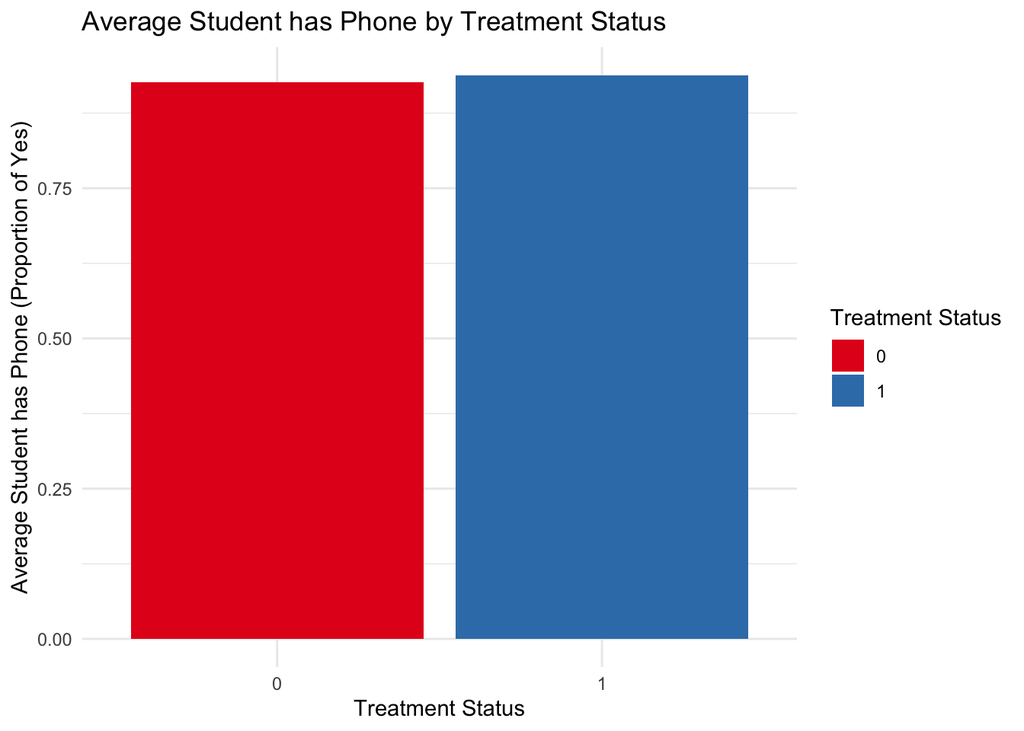

```r
set.seed(1234)

# Generate a vector that randomly assigns each unit to treatment/control
n <- nrow(df)

# I will assing a variable 0 for control and 1 for treatment
df$random_treat <- sample(c(0, 1), n, replace = TRUE)
df$random_treat <- as.factor(df$random_treat)

# Choose a baseline covariate (use dplyr for this)
student_Phone_var <- df %>%
  group_by(random_treat) %>%
  summarise(student_Phone_mean = mean(student_Phone))

# Visualize the distribution by treatment/control (ggplot)

#   bar plot
ggplot(student_Phone_var, aes(x = random_treat, y = student_Phone_mean, fill = random_treat)) +
  geom_bar(stat = "identity") +
  theme_minimal() +
  labs(title = "Average Student has Phone by Treatment Status",
       x = "Treatment Status",
       y = "Average Student has Phone (Proportion of Yes)") +
  scale_fill_brewer(palette = "Set1", name = "Treatment Status")
```

```r
#Doing a Chi2 test
table_data <- table(df$student_Phone, df$random_treat)
chi2_result <- chisq.test(table_data)

# and a ttest
t.test( student_Phone~ random_treat, data = df)
```

```
##
##  Welch Two Sample t-test
##
## data:  student_Phone by random_treat
## t = -0.79899, df = 1250.6, p-value = 0.4244
## alternative hypothesis: true difference in means between group 0 and group 1 is not equal to 0
## 95 percent confidence interval:
##  -0.03915929  0.01649385
## sample estimates:
## mean in group 0 mean in group 1
##       0.9266771       0.9380098
```

```r
#No statistical difference, thus no difference in the distribution


# Simulate this 10,000 times (monte carlo simulation - see R Refresher for a hint)

n_iterations <- 10000

#we will store results
results <- data.frame(iteration = integer(n_iterations),
                      chi2_p_value = numeric(n_iterations),
                      ttest_p_value = numeric(n_iterations),
                      treatment_mean = numeric(n_iterations),
                      control_mean = numeric(n_iterations),
                      mean_differences <- numeric(n_iterations))

for (i in 1:n_iterations) {
# I will assing a variable 0 for control and 1 for treatment
df$random_treat <- sample(c(0, 1), n, replace = TRUE)
df$random_treat <- as.factor(df$random_treat)

# Choose a baseline covariate (use dplyr for this)
student_Phone_var <- df %>%
  group_by(random_treat) %>%
  summarise(student_Phone_mean = mean(student_Phone))

  # Store means
  results$treatment_mean[i] <- student_Phone_var$student_Phone_mean[df$random_treat == 1]
  results$control_mean[i] <- student_Phone_var$student_Phone_mean[df$random_treat == 0]

  # Chi-squared test
  table_data <- table(df$student_Phone, df$random_treat)
  chi2_result <- chisq.test(table_data)
  results$chi2_p_value[i] <- chi2_result$p.value

  # T-test
  ttest_result <- t.test(student_Phone ~ random_treat, data = df)
  results$ttest_p_value[i] <- ttest_result$p.value

    # Calculate the difference in means
  treatment_mean <- student_Phone_var$student_Phone_mean[df$random_treat == 1]
  control_mean <- student_Phone_var$student_Phone_mean[df$random_treat == 0]
  mean_differences[i] <- treatment_mean - control_mean


  # iteration number
  results$iteration[i] <- i
}


mean(results$chi2_p_value < 0.05)
```

```
## [1] 0.0369
```

```r
mean(results$ttest_p_value < 0.05)
```

```
## [1] 0.0464
```

```r
# Analyze the balance of the variable
mean_difference_test <- t.test(mean_differences)
mean_difference_test
```

```
##
##  One Sample t-test
##
## data:  mean_differences
## t = 2.245, df = 5040, p-value = 0.02481
## alternative hypothesis: true mean is not equal to 0
## 95 percent confidence interval:
##  0.00005714814 0.00084451486
## sample estimates:
##    mean of x
## 0.0004508315
```

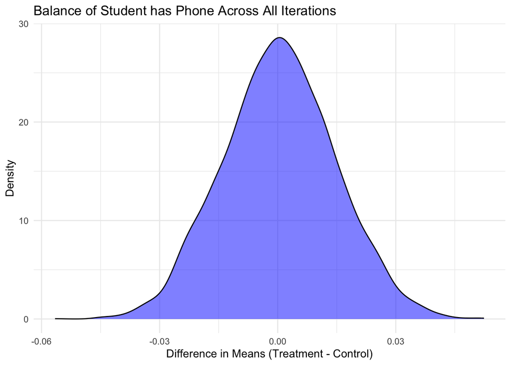

```r
# Visualize the balance of the variable
dist_studphone <- ggplot(data.frame(MeanDifference = mean_differences), aes(x = MeanDifference)) +
  geom_density(fill = "blue", alpha = 0.5) +
  geom_vline(xintercept = mean(mean_differences), linetype = "dashed", color = "red") +
  labs(title = "Balance of Student has Phone Across All Iterations",
       x = "Difference in Means (Treatment - Control)",
       y = "Density") +
  theme_minimal()
dist_studphone
```

Questions

Your Answer: My graph is showing that the difference of the mean of the variable student having a phone, is centered at $0$, which means that it could be that by pure chance we can end up having no difference in most of the times. Also, it shows that there will be some cases where the mean will be higher or lower than zero, following a normal distribution. It also means that even with independence of treatment some cases will be unbalanced, although all the distribution is contained within the threshold of $0.1$ It is important to recognize that depending on the underlying distribution of the data, even with randommization there could be inbalances on some covariates.

# Propensity Score Matching

## One Model

Select covariates that you think best represent the “true” model predicting whether a student chooses to attend college, and estimate a propensity score model to calculate the Average Treatment Effect on the Treated (ATT). Plot the balance of the top 10 (or fewer if you select fewer covariates). Report the balance of the p-scores across both the treatment and control groups, and using a threshold of standardized mean difference of p-score $\leq .1$, report the number of covariates that meet that balance threshold.

```r
# Select covariates that represent the "true" model for selection, fit model
#variable_names <- names(df)
#df_variable_names <- data.frame(VariableName = variable_names)

select_variables <- c("student_PubAff" ,
"student_Newspaper" ,
"student_Radio" ,
"student_TV" ,
"student_Magazine" ,
"student_FamTalk" ,
"student_FrTalk" ,
"student_AdultTalk" ,
"student_PID" ,
"student_SPID" ,
"student_GovtOpinion" ,
"student_Cynic" ,
"student_StrOpinion" ,
"student_TrOthers" ,
"student_Trust" ,
"student_Senate" ,
"student_Tito" ,
"student_Court" ,
"student_Govern" ,
"student_CCamp" ,
"student_FDR" ,
"student_Knowledge" ,
"student_NextSch" ,
"student_GPA" ,
"student_SchPublish" ,
"student_Phone" ,
"student_Gen" ,
"student_Race" ,
"parent_Newspaper" ,
"parent_Radio" ,
"parent_TV" ,
"parent_Magazine" ,
"parent_TrOthers" ,
"parent_OthHelp" ,
"parent_OthFair" ,
"parent_PolClub" ,
"parent_Button" ,
"parent_Money" ,
"parent_Participate1" ,
"parent_Participate2" ,
"parent_GovtOpinion" ,
"parent_Employ" ,
"parent_EducHH" ,
"parent_EducW" ,
"parent_CivicOrg" ,
"parent_HHInc" ,
"parent_OwnHome" ,
"parent_Senate" ,
"parent_Tito" ,
"parent_Court" ,
"parent_Govern" ,
"parent_CCamp" ,
"parent_Knowledge" ,
"parent_Gen" ,
"parent_Race"  )

ps_formula <- as.formula(paste("college ~", paste(select_variables, collapse = " + ")))

match_ps_att <-matchit(formula = ps_formula, data = df,  # formula
                          method = "nearest", # method
                          distance = "glm",
                          discard = "control" ,
                          replace = TRUE ,
                         ratio = 2) # estimand
# summary
summary(match_ps_att, un = FALSE )
```

```
##
## Call:
## matchit(formula = ps_formula, data = df, method = "nearest",
##     distance = "glm", discard = "control", replace = TRUE, ratio = 2)
##
## Summary of Balance for Matched Data:
##                     Means Treated Means Control Std. Mean Diff. Var. Ratio
## distance                   0.7884        0.7846          0.0182     1.0019
## student_PubAff             0.9465        0.9882         -0.1853          .
## student_Newspaper          1.9427        1.9626         -0.0152     1.1294
## student_Radio              2.6401        2.6096          0.0172     0.9461
## student_TV                 2.2167        2.0735          0.1121     1.1330
## student_Magazine           1.6139        1.4458          0.1927     1.1662
## student_FamTalk            1.8431        1.7503          0.1007     1.2845
## student_FrTalk             1.9938        1.9271          0.0704     0.8081
## student_AdultTalk          2.9614        3.1544         -0.1856     0.9614
## student_PID                3.6314        2.9078          0.3705     1.1805
## student_SPID               1.7360        1.8381         -0.1057     0.9537
## student_GovtOpinion        1.5965        1.4745          0.1916     0.9482
## student_Cynic              2.7011        2.4191          0.2283     1.1321
## student_StrOpinion         1.7796        1.5710          0.2157     1.1300
## student_TrOthers           1.6413        1.4832          0.1704     1.1420
## student_Trust              3.1283        3.2802         -0.1490     1.0100
## student_Senate             0.5965        0.5660          0.0622          .
## student_Tito               0.3599        0.2858          0.1544          .
## student_Court              0.4819        0.3269          0.3103          .
## student_Govern             0.9377        0.9433         -0.0232          .
## student_CCamp              0.9278        0.9278          0.0000          .
## student_FDR                0.7472        0.7098          0.0860          .
## student_Knowledge          0.6752        0.6266          0.2133     1.0010
## student_NextSch            0.9577        0.9477          0.0495          .
## student_GPA                2.2740        2.1687          0.1607     1.0579
## student_SchPublish         1.7111        1.6955          0.0136     1.0807
## student_Phone              0.9614        0.9533          0.0420          .
## student_Gen                0.5479        0.4122          0.2727          .
## student_Race               1.0822        1.2005         -0.3880     0.5500
## parent_Newspaper           3.3674        3.4271         -0.0481     1.1011
## parent_Radio               2.4770        2.4695          0.0042     1.0005
## parent_TV                  3.2130        3.2435         -0.0250     1.1359
## parent_Magazine            0.6600        0.5081          0.3207          .
```

[output cut: 73 more lines]

```
## parent_Tito            0.0374   0.0374          0.8178
## parent_Court           0.0473   0.0473          0.7906
## parent_Govern          0.0006   0.0006          0.3496
## parent_CCamp           0.0293   0.0293          0.6306
## parent_Knowledge       0.0242   0.0666          0.9796
## parent_Gen             0.0012   0.0012          1.0144
## parent_Race            0.0440   0.1258          0.8586
##
## Sample Sizes:
##               Control Treated
## All            451.       803
## Matched (ESS)   33.56     803
## Matched        257.       803
## Unmatched      160.         0
## Discarded       34.         0
```

```r
match_ps_att_data <- match.data(match_ps_att)

att_formula <- as.formula(paste("student_ppnscal ~ college +", paste(select_variables, collapse = " + ")))

lm_ps_att <- lm(att_formula, data = match_ps_att_data, weights = weights )

lm_ps_att_summ <- summary(lm_ps_att)
lm_ps_att_summ
```

```
##
## Call:
## lm(formula = att_formula, data = match_ps_att_data, weights = weights)
##
## Weighted Residuals:
##     Min      1Q  Median      3Q     Max
## -4.7659 -1.1380 -0.1298  0.8694  5.8407
##
## Coefficients: (1 not defined because of singularities)
##                      Estimate Std. Error t value         Pr(>|t|)
## (Intercept)          0.033420   0.976124   0.034         0.972694
## college              0.941429   0.131970   7.134 0.00000000000187 ***
## student_PubAff      -0.137572   0.270533  -0.509         0.611199
## student_Newspaper    0.027934   0.046083   0.606         0.544537
## student_Radio       -0.017596   0.032404  -0.543         0.587230
## student_TV          -0.088588   0.047125  -1.880         0.060421 .
## student_Magazine    -0.193223   0.067451  -2.865         0.004262 **
## student_FamTalk     -0.091391   0.067605  -1.352         0.176735
## student_FrTalk       0.013031   0.061496   0.212         0.832226
## student_AdultTalk   -0.158861   0.055168  -2.880         0.004067 **
## student_PID         -0.069609   0.030507  -2.282         0.022714 *
## student_SPID         0.039599   0.059352   0.667         0.504804
## student_GovtOpinion -0.063553   0.091190  -0.697         0.486009
## student_Cynic        0.032349   0.049348   0.656         0.512274
## student_StrOpinion  -0.198450   0.060200  -3.297         0.001013 **
## student_TrOthers     0.028580   0.095143   0.300         0.763944
## student_Trust        0.080314   0.086725   0.926         0.354625
## student_Senate      -0.009795   0.119449  -0.082         0.934664
## student_Tito         0.438983   0.130278   3.370         0.000781 ***
## student_Court       -0.061407   0.118236  -0.519         0.603623
## student_Govern       0.356533   0.236369   1.508         0.131774
## student_CCamp        0.437227   0.218937   1.997         0.046090 *
## student_FDR          0.116801   0.132566   0.881         0.378487
## student_Knowledge          NA         NA      NA               NA
## student_NextSch      0.020597   0.268595   0.077         0.938889
## student_GPA          0.136628   0.093712   1.458         0.145164
## student_SchPublish   0.151124   0.050766   2.977         0.002982 **
## student_Phone       -0.277876   0.281627  -0.987         0.324036
## student_Gen          0.066086   0.120350   0.549         0.583046
## student_Race        -0.483179   0.452459  -1.068         0.285824
```

[output cut: 18 more lines]

```
## parent_OwnHome      -0.480219   0.153888  -3.121         0.001857 **
## parent_Senate       -0.925871   0.310177  -2.985         0.002905 **
## parent_Tito         -0.705957   0.306284  -2.305         0.021375 *
## parent_Court        -0.693641   0.291781  -2.377         0.017628 *
## parent_Govern       -1.090401   0.433846  -2.513         0.012115 *
## parent_CCamp        -0.549733   0.367592  -1.495         0.135099
## parent_Knowledge     4.543414   1.639504   2.771         0.005688 **
## parent_Gen          -0.287732   0.143938  -1.999         0.045877 *
## parent_Race          1.069616   0.463337   2.309         0.021173 *
## ---
## Signif. codes:  0 '***' 0.001 '**' 0.01 '*' 0.05 '.' 0.1 ' ' 1
##
## Residual standard error: 1.71 on 1004 degrees of freedom
## Multiple R-squared:  0.207,  Adjusted R-squared:  0.1636
## F-statistic: 4.766 on 55 and 1004 DF,  p-value: < 0.00000000000000022
```

```r
ATT_ps <- lm_ps_att_summ$coefficients["college", "Estimate"]
ATT_ps
```

```
## [1] 0.9414291
```

```r
# BALANCE
balance_table <- bal.tab(match_ps_att, un = FALSE)
# Ensure we are accessing the standardized mean differences correctly
effect_sizes <- abs(balance_table$Balance$Diff.Adj)
names(effect_sizes) <- rownames(balance_table$Balance)

# Step 2: Identify the Top 10 Covariates Based on Effect Size
top_10_covariates <- names(sort(effect_sizes, decreasing = TRUE)[1:10])
print(top_10_covariates)
```

```
##  [1] "parent_Race"        "student_Race"       "student_PID"
##  [4] "parent_EducW"       "parent_EducHH"      "student_Cynic"
##  [7] "student_StrOpinion" "student_Knowledge"  "parent_HHInc"
## [10] "student_Magazine"
```

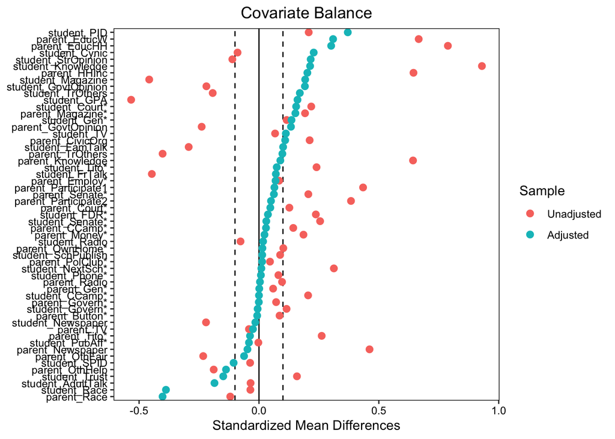

```r
# Step 3: Create a Love Plot for Top 10 Covariates
love.plot(match_ps_att, thresholds = c(m = 0.1), stars="raw", drop.distance = TRUE, var.order="adjusted")
```

```r
# Assess the Balance
# Recheck the balance table for the selected top 10 covariates
balance_table_selected <- bal.tab(match_ps_att, vars = top_10_covariates, un = FALSE)
# Checking the number of covariates with SMD ≤ 0.1 among the top 10
balanced_covariates <- sum(abs(balance_table_selected$Balance$Diff.Adj) <= 0.1)
balanced_covariates
```

```
## [1] 32
```

## Simulations

Henderson/Chatfield argue that an improperly specified propensity score model can actually the bias of the estimate. To demonstrate this, they simulate 800,000 different propensity score models by choosing different permutations of covariates. To investigate their claim, do the following:

```r
# Remove post-treatment covariates
# I will also remove interview id and rows that have missing variables
baseline_vars <- colnames(ypsps)[!grepl("1973", colnames(ypsps)) &
                                 !grepl("1982", colnames(ypsps)) &
                                 colnames(ypsps) != "interviewid" &
                                 colnames(ypsps) != "student_ppnscal"]

# Remove rows with missing values in the selected columns
ypsps_clean <- ypsps[complete.cases(ypsps[, baseline_vars]), ]


# Print the filtered list of variable names
print(baseline_vars)
```

```
##   [1] "college"                    "student_vote"
##   [3] "student_meeting"            "student_other"
##   [5] "student_button"             "student_money"
##   [7] "student_communicate"        "student_demonstrate"
##   [9] "student_community"          "student_PubAff"
##  [11] "student_Newspaper"          "student_Radio"
##  [13] "student_TV"                 "student_Magazine"
##  [15] "student_FamTalk"            "student_FrTalk"
##  [17] "student_AdultTalk"          "student_PID"
##  [19] "student_SPID"               "student_GovtOpinion"
##  [21] "student_GovtCrook"          "student_GovtWaste"
##  [23] "student_TrGovt"             "student_GovtSmart"
##  [25] "student_Govt4All"           "student_Cynic"
##  [27] "student_LifeWish"           "student_GLuck"
##  [29] "student_FPlans"             "student_EgoA"
```

[output cut: 45 more lines]

```r
# Randomly select features
# I tried with more iterations, but after a while having to rerun the code as I was debugging I had to settle with 100, to keep it real.
set.seed(123)
n_iterations <- 100
results <- vector("list", n_iterations)

data_simulation <- data.frame(run_id = integer(),
                              n_covar = integer(),
                              ATT = double(),
                              pct_balanced = double(),
                              mean_pct_impr=double())



for (i in 1:n_iterations) {
  # Randomly select a number of variables from baseline_vars
  n_vars <- sample(1:length(baseline_vars), 1)
  selected_vars <- sample(baseline_vars, n_vars)

  # Create and perform matching using selected_vars
  formula_str <- paste("college ~", paste(selected_vars, collapse = " + "))
  formula <- as.formula(formula_str)
  matchit_res <- matchit(formula, data = ypsps_clean, method = "nearest" ,
                         distance = "glm",# use glm, which by default is logistic regression
                         link = "logit",# specify we want a logit model, default when distance is specified
                         estimand="ATT",
                         discard = "control",# obs to be discarded that are outside region of common support
                         replace = TRUE,# whether matching should be done with replacement
                         ratio = 2)

  # Estimate ATT using linear regression on the matched data
  matched_data <- match.data(matchit_res)
  lm_formula <- as.formula(paste("student_ppnscal ~ college +", paste(selected_vars, collapse = " + ")))
  att_model <- lm(lm_formula, data = matched_data, weights=weights)
  att <- coef(summary(att_model))["college", "Estimate"]


  # Calculate the proportion of covariates with SMD ≤ 0.1 and mean percent improvement in SMD
  balance<- bal.tab(matchit_res , binary="std", m.threshold=0.1 )
  df_balance <- as.data.frame(balance$Balance$M.Threshold)

  n_total <- nrow(df_balance)
  n_balanced <- length(df_balance[which(balance$Balance$M.Threshold == "Balanced, <0.1"),])
  pct_balanced <- (n_balanced/n_total)

   #Calculate the mean of the improvement
matchit_summary <- summary(matchit_res, improvement = TRUE)

# Extract the reduction in standardized mean differences
improvement_data <- matchit_summary$reduction

smd_reduction <- improvement_data[,"Std. Mean Diff."]

# Calculate mean percent
mean_percent_improvement <- mean(smd_reduction, na.rm = TRUE)



  # put all this into a dataframe
  data_sim <- data.frame(run_id = i,
                          n_covar = n_vars,
                          ATT = att,
                          pct_balanced = pct_balanced,
                         mean_pct_impr=mean_percent_improvement)

  data_simulation <- rbind(data_simulation, data_sim)

 results[[i]] <- list(
    formula = formula_str,
    ATT = att,
    mean_improvement_smd = mean_percent_improvement,
    model = matchit_res
  )
}


pct_balanced_sim_mean <- mean(data_simulation$pct_balanced)
pct_balanced_sim_mean
```

```
## [1] 0.4017319
```

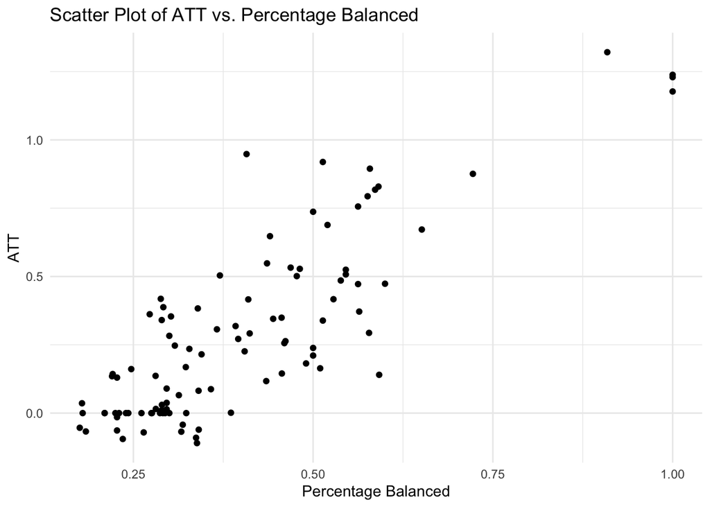

```r
# Simulate random selection of features 10k+ times

# Fit p-score models and save ATTs, proportion of balanced covariates, and mean percent balance improvement

# Plot ATT v. proportion

ggplot(data_simulation, aes(x =pct_balanced, y = ATT)) +
  geom_point() +  # Add points
  theme_minimal() +  # Use a minimal theme for aesthetics
  labs(x = "Percentage Balanced", y = "ATT",
       title = "Scatter Plot of ATT vs. Percentage Balanced")
```

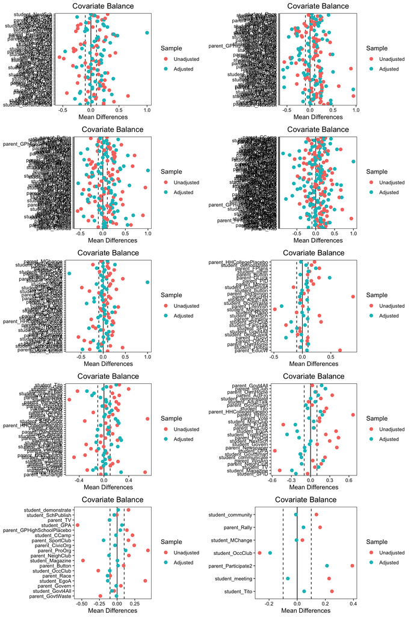

```r
# 10 random covariate balance plots (hint try gridExtra)


set.seed(456)
selected_indices <- sample(length(results), 10)
selected_models <- results[selected_indices]

library(gridExtra)
plot_list <- lapply(selected_models, function(model) {
  # Extract the matchit object
  matchit_obj <- model$model

  # Create the Love plot
  p <- love.plot(matchit_obj, print = FALSE, drop.distance = TRUE, thresholds = c(m = 0.1))
  return(p)
})

# Arrange the plots in a grid
grid.arrange(grobs = plot_list, ncol = 2)
```

```r
# Note: ggplot objects are finnicky so ask for help if you're struggling to automatically create them; consider using functions!
```

# Matching Algorithm of Your Choice

## Simulate Alternative Model

Henderson/Chatfield propose using genetic matching to learn the best weights for Mahalanobis distance matching. Choose a matching algorithm other than the propensity score (you may use genetic matching if you wish, but it is also fine to use the greedy or optimal algorithms we covered in lab instead). Repeat the same steps as specified in Section 4.2 and answer the following questions:

```r
#alternative model

# I will also remove interview id and rows that have missing variables
baseline_vars <- colnames(ypsps)[!grepl("1973", colnames(ypsps)) &
                                 !grepl("1982", colnames(ypsps)) &
                                 colnames(ypsps) != "interviewid" &
                                 colnames(ypsps) != "student_ppnscal"]

# Remove rows with missing values in the selected columns
ypsps_clean <- ypsps[complete.cases(ypsps[, baseline_vars]), ]


# Print the filtered list of variable names
#print(baseline_vars)

# I will comment all to avoid running all again .
# Randomly select features

#set.seed(546)

# It tried running a 1000, it was too much. I stopped the code at 198. Ill do the analysis with that.
#n_iterations <- 198
#data_simulation2 <- data.frame(run_id = integer(),
                        #      n_covar = integer(),
                        #      ATT = double(),
                        #      pct_balanced = double(),
                         #     mean_pct_impr = double())



#for (i in 1:n_iterations) {
  # Randomly select a number of variables from baseline_vars
 # n_vars <- sample(1:length(baseline_vars), 1)
 # selected_vars <- sample(baseline_vars, n_vars)

  # Create and perform matching using selected_vars
  #formula_str <- paste("college ~", paste(selected_vars, collapse = " + "))
  #formula <- as.formula(formula_str)
  #matchit_res2 <- matchit(formula, data = ypsps_clean, method = "genetic" ,
                  #       distance = "glm",# use glm, which by default is logistic regression
                    #     link = "logit",# specify we want a logit model, default when distance is specified
                    #     estimand="ATT",
                    #     discard = "none",# obs to be discarded that are outside region of common support
                         # whether matching should be done with replacement
                     #    ratio = 1)

  # Estimate ATT using linear regression on the matched data
 # matched_data2 <- match.data(matchit_res2)
 # lm_formula <- as.formula(paste("student_ppnscal ~ college +", paste(selected_vars, collapse = " + ")))
  #att_model2 <- lm(lm_formula, data = matched_data2, weights=weights)
  #att2 <- coef(summary(att_model2))["college", "Estimate"]


  # Calculate the proportion of covariates with SMD ≤ 0.1 and mean percent improvement in SMD
  #balance2<- bal.tab(matchit_res2 , binary="std", m.threshold=0.1 )
 # df_balance2 <- as.data.frame(balance2$Balance$M.Threshold)

#  n_total2 <- nrow(df_balance2)
 # n_balanced2 <- length(df_balance2[which(balance2$Balance$M.Threshold == "Balanced, <0.1"),])
 # pct_balanced2 <- (n_balanced2/n_total2)


#matchit_summary2 <- summary(matchit_res2, improvement = TRUE)

# Extract the reduction in standardized mean differences
#improvement_data2 <- matchit_summary2$reduction

# Specifically, if you're interested in the reduction of SMDs
#smd_reduction2 <- improvement_data2[,"Std. Mean Diff."]

# You can calculate the mean percent improvement if needed
#mean_percent_improvement2 <- mean(smd_reduction2, na.rm = TRUE)



  # put all this into a dataframe
#  data_sim2 <- data.frame(run_id = i,
 #                         n_covar = n_vars,
 #                         ATT = att2,
 #                         pct_balanced2 = pct_balanced2,
 #                         mean_pct_impr2=mean_percent_improvement2)

#  data_simulation2 <- rbind(data_simulation2, data_sim2)

#}
```

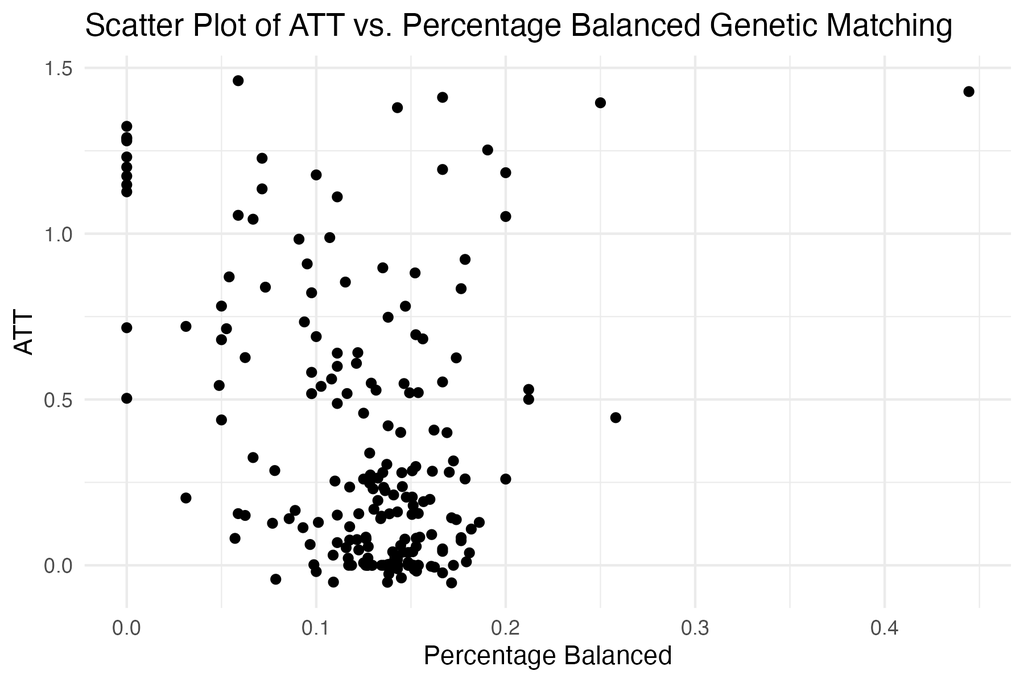

GraphGen

```r
# Plot ATT v. proportion

#graph_genetic <- ggplot(data_simulation2, aes(x =pct_balanced2, y = ATT)) +
 # geom_point() +  # Add points
  #theme_minimal() +  # Use a minimal theme for aesthetics
  #labs(x = "Percentage Balanced", y = "ATT",
   #    title = "Scatter Plot of ATT vs. Percentage Balanced Genetic Matching")
#graph_genetic
#ggsave("graph_genetic.png", graph_genetic, width = 6, height = 4)
```

```r
# Percentage balanced
#mean_pct_bal_genetic <- mean(data_simulation2$pct_balanced2)
#mean_pct_bal_nn <- mean(data_simulation$pct_balanced)
#mean_pct_bal_genetic
#mean_pct_bal_nn
```

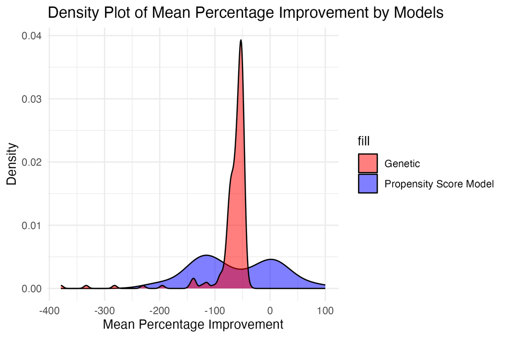

GraphDensities

```r
# Visualization for distributions of percent improvement

#graph_denisities <- ggplot() +
 # geom_density(data = data_simulation, aes(x = mean_pct_impr, fill = "Propensity Score Model"), alpha = 0.5) +
  #geom_density(data = data_simulation2, aes(x = mean_pct_impr2, fill = "Genetic"), alpha = 0.5) +
  #labs(title = "Density Plot of Mean Percentage Improvement by Models",
   #    x = "Mean Percentage Improvement",
    # y = "Density") +
  #scale_fill_manual(values = c("Propensity Score Model" = "blue", "Genetic" = "red")) +
  #theme_minimal()

#ggsave("graph_denisities.png", graph_denisities, width = 6, height = 4)
```

## Questions

Looking ahead to the discussion questions, you may choose to model the propensity score using an algorithm other than logistic regression and perform these simulations again, if you wish to explore the second discussion question further.